# Linear Regression models test: Life satisfaction prediction

by JUMEX365

### All the necessary packages

```r
library(MASS)
library(lm.beta)
library(car)
```

```r
library(foreign)
library(ggplot2)
library(plyr)
library(nortest)
```

### Loading data

```r
fulldata <- read.spss("HBSC 2014 5 countries.sav", use.value.label=T, to.data.frame=T)
```

### Select variables

```r
mod1 <- fulldata [c("AGE","sex", "lifesat", "studaccept", "teacheraccept")]
```

### Editing data

```r
mod1$AGE <-  round(mod1$AGE)
mod1 <- na.omit(mod1)

mod1$lifesat  <- revalue(mod1$lifesat, c("10, best possible life"="10"))
mod1$lifesat <- revalue(mod1$lifesat, c("0, worst possible life"="0"))

mod1$studaccept <- revalue(mod1$studaccept, c("Strongly disagree"="1"))
mod1$studaccept <- revalue(mod1$studaccept, c("Disagree"="2"))
mod1$studaccept <- revalue(mod1$studaccept, c("Neither agree/disagree"="3"))
mod1$studaccept <- revalue(mod1$studaccept, c("Agree"="4"))
mod1$studaccept <- revalue(mod1$studaccept, c("Strongly agree"="5"))

mod1$teacheraccept <- revalue(mod1$teacheraccept, c("Strongly disagree"="1"))
mod1$teacheraccept <- revalue(mod1$teacheraccept, c("Disagree"="2"))
mod1$teacheraccept <- revalue(mod1$teacheraccept, c("Neither agree/disagree"="3"))
mod1$teacheraccept <- revalue(mod1$teacheraccept, c("Agree"="4"))
mod1$teacheraccept <- revalue(mod1$teacheraccept, c("Strongly agree"="5"))

mod1$studaccept <- as.numeric(mod1$studaccept)
mod1$teacheraccept <- as.numeric(mod1$teacheraccept)
mod1$lifesat <- as.numeric(mod1$lifesat)
mod1$sex <-as.factor(mod1$sex)
```

*Dependent variable:*

- Life satisfaction is evaluated: from 1 to 11

*Independent variables:*

- Acceptance by students: from 1 to 5
- Acceptance by teachers: from 1 to 5

*Control variables*

- Sex: boy/girl
- Age: from 10 to 16

### Part 1 (Model)

```r
model_1 <- lm(mod1$lifesat~mod1$sex+mod1$AGE+mod1$studaccept+mod1$teacheraccept)
summary(model_1)
```

```
##
## Call:
## lm(formula = mod1$lifesat ~ mod1$sex + mod1$AGE + mod1$studaccept +
##     mod1$teacheraccept)
##
## Residuals:
##     Min      1Q  Median      3Q     Max
## -8.8256 -0.9321  0.3043  1.2670  5.1617
##
## Coefficients:
##                     Estimate Std. Error t value Pr(>|t|)
## (Intercept)        12.178702   0.094621  128.71   <2e-16 ***
## mod1$sexGirl       -0.317429   0.022909  -13.86   <2e-16 ***
## mod1$AGE           -0.140066   0.006913  -20.26   <2e-16 ***
## mod1$studaccept    -0.446724   0.012225  -36.54   <2e-16 ***
## mod1$teacheraccept -0.365689   0.012768  -28.64   <2e-16 ***
## ---
## Signif. codes:  0 '***' 0.001 '**' 0.01 '*' 0.05 '.' 0.1 ' ' 1
##
## Residual standard error: 1.805 on 24885 degrees of freedom
## Multiple R-squared:  0.1404, Adjusted R-squared:  0.1402
## F-statistic:  1016 on 4 and 24885 DF,  p-value: < 2.2e-16
```

Description:

- Girl have lover life satisfaction (on ~0.3 points/11)
- Each extra age of life makes life satisfaction be lower (on 0.14 points/11)
- Each extra point of acceptance by students correlate with decrease of life satisfaction (on ~0.45 points/11)
- Each extra point of acceptance by teachers correlate with decline of life satisfaction (on ~0.36 points/11)

All the relationships are significant (*** + low p-value), we an observe negative correlation. r^2= 0.14, so model explain 14% of data, so model is not excellent.

### Part 2 (Interactive effect)

```r
model_2 <- lm(mod1$lifesat~mod1$sex*mod1$studaccept+mod1$teacheraccept*mod1$AGE)
summary(model_2)
```

```
##
## Call:
## lm(formula = mod1$lifesat ~ mod1$sex * mod1$studaccept + mod1$teacheraccept *
##     mod1$AGE)
##
## Residuals:
##     Min      1Q  Median      3Q     Max
## -8.8351 -0.9492  0.3001  1.2727  5.2806
##
## Coefficients:
##                               Estimate Std. Error t value Pr(>|t|)
## (Intercept)                  12.785604   0.208916  61.200  < 2e-16 ***
## mod1$sexGirl                 -0.130679   0.051058  -2.559 0.010491 *
## mod1$studaccept              -0.394878   0.017265 -22.871  < 2e-16 ***
## mod1$teacheraccept           -0.755473   0.101398  -7.451 9.60e-14 ***
## mod1$AGE                     -0.192106   0.015309 -12.549  < 2e-16 ***
## mod1$sexGirl:mod1$studaccept -0.097188   0.023490  -4.137 3.52e-05 ***
## mod1$teacheraccept:mod1$AGE   0.028452   0.007336   3.878 0.000106 ***
## ---
## Signif. codes:  0 '***' 0.001 '**' 0.01 '*' 0.05 '.' 0.1 ' ' 1
##
## Residual standard error: 1.804 on 24883 degrees of freedom
## Multiple R-squared:  0.1415, Adjusted R-squared:  0.1413
## F-statistic: 683.5 on 6 and 24883 DF,  p-value: < 2.2e-16
```

Description:

- Girl have lover life satisfaction (on ~0.13 points/11)
- Each extra point of acceptance by students correlate with decrease of life satisfaction (on ~0.39 points/11)
- Each extra point of acceptance by teachers correlate with decline of life satisfaction (on ~0.75 points/11)
- Each extra age of life makes life satisfaction be lower (on ~ 0.19 points/11)

Interaction:

- For girls each extra point of acceptance by students correlate with decrease of life satisfaction (on ~0.1 points/11)
- Older students, who are accepted by teachers have higher life satisfaction (the only positive correlation)

Other correlations are negate and statistically significant (low p-value). Model explains 14% of observations.

### Part 3 (Check for a non-linear effect)

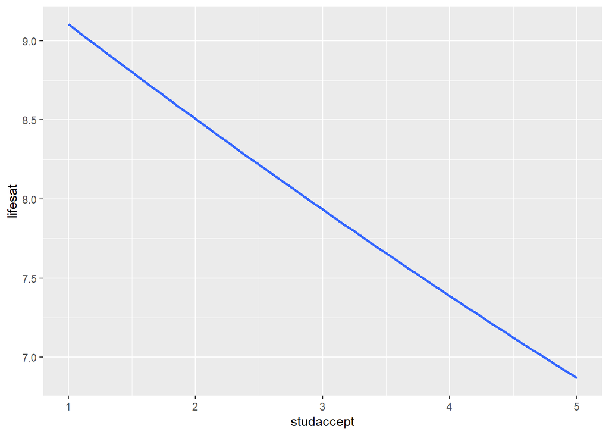

```r
ggplot(mod1, aes(x=studaccept, y=lifesat)) +
stat_smooth(se=F, method = 'lm', formula = y~x+I(x^2))
```

There is no non-linear effect.

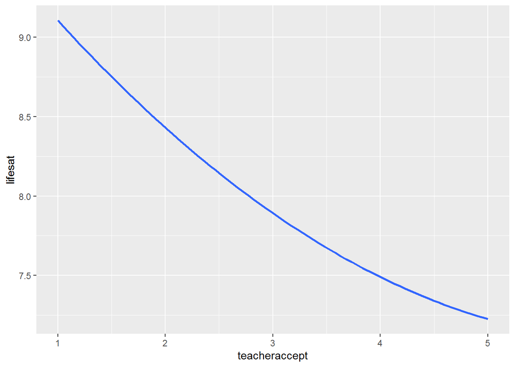

```r
ggplot(mod1, aes(x=teacheraccept, y=lifesat)) +
stat_smooth(se=F, method = 'lm', formula = y~x+I(x^2))
```

There is non linear effect. -> quadratic effect

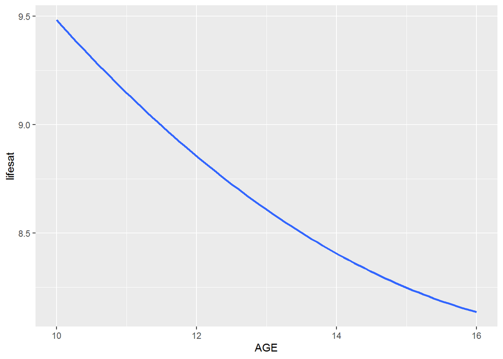

```r
ggplot(mod1, aes(x=AGE, y=lifesat)) +
stat_smooth(se=F, method = 'lm', formula = y~x+I(x^2))
```

There is non linear effect. -> quadratic effect

### Part 4 (which model is better)

```r
anova (model_1, model_2)
```

```
## Analysis of Variance Table
##
## Model 1: mod1$lifesat ~ mod1$sex + mod1$AGE + mod1$studaccept + mod1$teacheraccept
## Model 2: mod1$lifesat ~ mod1$sex * mod1$studaccept + mod1$teacheraccept *
##     mod1$AGE
##   Res.Df   RSS Df Sum of Sq      F    Pr(>F)
## 1  24885 81067
## 2  24883 80964  2    103.71 15.937 1.211e-07 ***
## ---
## Signif. codes:  0 '***' 0.001 '**' 0.01 '*' 0.05 '.' 0.1 ' ' 1
```

Null hypothesis: more simple model (№1) is better.

Here we have really small p-value, so we reject null hypothesis. So model_2 is better.

### Part 5 (which model is better)

### Heteroscedasticity

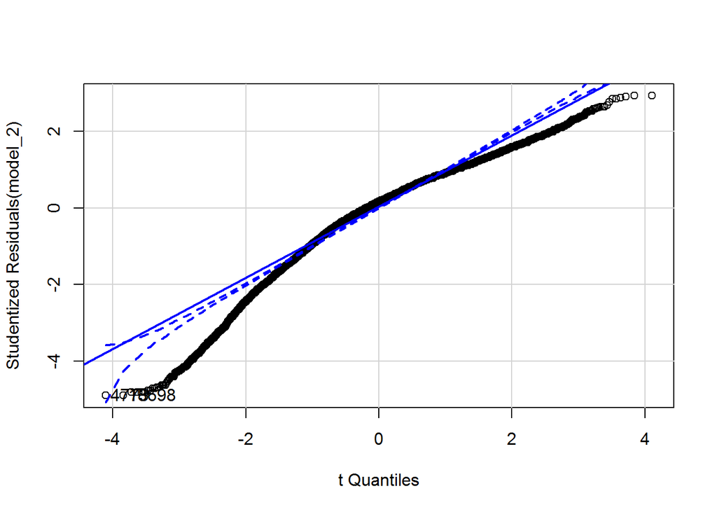

```
## [1]  4773 18698
```

```r
qqPlot(model_2)
```

Residuals significantly deviates from “blue” area, there is some issues with heteroscedasticity.

Lets perform test

```r
ncvTest(model_2)
```

```
## Non-constant Variance Score Test
## Variance formula: ~ fitted.values
## Chisquare = 917.5375, Df = 1, p = < 2.22e-16
```

P values is low, so it is significant. Definitely model have problem with heteroscedasticity.

### Outliers

```r
outlierTest(model_2)
```

```
##        rstudent unadjusted p-value Bonferroni p
## 4773  -4.901011         9.5944e-07     0.023881
## 18698 -4.901011         9.5944e-07     0.023881
## 747   -4.809909         1.5188e-06     0.037803
## 5581  -4.809909         1.5188e-06     0.037803
## 7347  -4.809909         1.5188e-06     0.037803
## 17832 -4.809909         1.5188e-06     0.037803
## 3461  -4.774480         1.8120e-06     0.045100
## 7954  -4.774480         1.8120e-06     0.045100
```

Null hypothesis: residuals do not have extreme outliers All the Bonferroni p <0.05, so we reject Null hypothesis. There are extreme outliers in each case.

### Distribution of residuals

```r
lillie.test(model_2$residuals)
```

```
##
##  Lilliefors (Kolmogorov-Smirnov) normality test
##
## data:  model_2$residuals
## D = 0.078361, p-value < 2.2e-16
```

Null hypothesis: distribution is normal.

P-value is low, so we reject null hypothesis.

Residuals is distributed not normally (there is issue).

*Generally model have significant problems, that are mentioned above.*